# Notebook 3 Visualizing Distributions (Teacher)

## Notebook 3: Visualizing Distributions

In the previous notebook, we used Pandas to select variables, filter observations, and summarize data. These data moves help us organize and analyze raw data so we can begin to identify patterns.

In this notebook, we build on that work by introducing data visualization using a Python library called Matplotlib. Visualizations help us see patterns and relationships that can be difficult to identify from numbers alone. While numerical summaries tell us what is happening, visualizations help us see distributions and relationships across variables.

In this notebook, you will:

- Create plots and charts using Matplotlib.
- Examine distributions of variables.
- Compare groups across different variables.

### 1.0 - Python Libraries

In our workflow, Pandas is still used to load, organize, and analyze the data. However, visualizing the data requires a different tool. To create plots and charts in Python, we will use the Matplotlib library.

Run the code cell below to import the Pandas library and the Pyplot module from the Matplotlib library.

**Note:** Matplotlib is a full visualization library that contains many different modules. Pyplot is the specific module that provides functions for creating plots and charts. Importing `matplotlib.pyplot` gives us the tools we need to make graphs without loading the entire library.

```python
## Run this code but do not edit it. Hit Ctrl+Enter to run the code
# This command imports pandas library and creates an alias named pd
import pandas as pd

# This command imports the matplotlib.pyplot module and creates an alias named plt
import matplotlib.pyplot as plt
plt.rcParams["figure.figsize"]=(12, 6)
```

**Instructor Note:** `plt.rcParams["figure.figsize"]=(12, 6)` is used to increase the default size of plots so labels, tick marks, and patterns are easier to see. This is especially helpful in Jupyter notebooks, where small default figures can make plots hard to read.

### 2.0 - Loading and Inspecting the Data

To begin, let's download our data. We'll download the `updated_gss.csv` from the Data Science 4 Everyone GitHub repository and store it into a `pandas` `DataFrame` object called `gss`.

### The Dataset (`updated_gss.csv`)

**General description:** The [General Social Survey (GSS)](https://gss.norc.org/) is a nationally representative survey of adults in the United States that was started in 1972. Conducted by the non-partisan [National Opinion Research Center (NORC)](https://www.norc.org/), the GSS collects data on a wide variety of topics in contemporary American society, including civil liberties, crime, intergroup tolerance, and social mobility. Its core purpose is to monitor and explain trends in opinions, attitudes, and behaviors.

The dataset used in this notebook is a subset of the full GSS, containing selected variables and survey years chosen to support instructional exploration and analysis. It also includes a cleaned version of the `wwwhr` column, with text-based response codes removed, replaced by missing values (`(NA)`), and remaining values converted to numeric.

**Description of all variables:** See [here.](https://ds4e-org.github.io/ap-cs-dsc-student/var.html)

**Detailed data file description:** See [here.](https://docs.google.com/spreadsheets/d/1AC6ZEz_00ZjoBBWrBpAgnybOqzFOsKFX/edit?gid=61928758#gid=61928758)

```python
## Run this code but do not edit it. Hit Ctrl+Enter to run the code
# This command downloads the data and stores it in the object gss
base_url = "https://raw.githubusercontent.com/ds4e-org/ap-cs-dsc/refs/heads/main/data/"
filename = "updated_gss.csv"
url = base_url + filename

gss = pd.read_csv(url)
```

**2.1 -** Use the `.head()` method to print out the first several rows of the dataset.

```python
# Your code goes here
gss.head()
```

|  | id | birth_year | survey_year | age | age_group | sex | reg16 | region | born | parborn | ... | natenvir | happy | happy7 | hapunhap | goodlife | opclout | ophrdwrk | opknow | opwlth | opeduc |
| --- | --- | --- | --- | --- | --- | --- | --- | --- | --- | --- | --- | --- | --- | --- | --- | --- | --- | --- | --- | --- | --- |
| 0 | 1 | 1955 | 1987 | 32 | 26-35 (Early Career) | MALE | Northeast | Northeast | YES | Both born in the U.S. | ... | TOO LITTLE | Pretty happy | .i: Inapplicable | .i: Inapplicable | Disagree | Not very important | Fairly important | Not very important | Fairly important | Fairly important |
| 1 | 2 | 1950 | 1987 | 37 | 36-50 (Mid Career) | FEMALE | Midwest | Northeast | YES | Both born in the U.S. | ... | .i: Inapplicable | Pretty happy | .i: Inapplicable | .i: Inapplicable | Disagree | Not very important | Fairly important | Fairly important | Fairly important | Very important |
| 2 | 5 | 1957 | 1987 | 30 | 26-35 (Early Career) | MALE | Northeast | Northeast | YES | Both born in the U.S. | ... | .i: Inapplicable | Not too happy | .i: Inapplicable | .i: Inapplicable | Disagree | Very important | Essential | Very important | Essential | Very important |
| 3 | 6 | 1955 | 1987 | 32 | 26-35 (Early Career) | MALE | Northeast | Northeast | YES | Neither born in the U.S. | ... | TOO LITTLE | Pretty happy | .i: Inapplicable | .i: Inapplicable | Agree | Not very important | Very important | Fairly important | Fairly important | Fairly important |
| 4 | 7 | 1958 | 1987 | 29 | 26-35 (Early Career) | FEMALE | Northeast | Northeast | YES | Both born in the U.S. | ... | .i: Inapplicable | Not too happy | .i: Inapplicable | .i: Inapplicable | Agree | Very important | Essential | Fairly important | Essential | Essential |

5 rows × 45 columns

**2.2 -** Use the `.shape` method to find the number of respondents (rows) and number of variables (columns).

```python
# Your code goes here
gss.shape
```

```
(21758, 45)
```

Another useful method for preliminary exploratory data analysis is the `.info()` method. It provides a quick summary of the dataframe’s structure, such as column names, data types, and the number of missing values `Non-Null Count`.

**2.3 -** Use the `.info()` method to print out information about the dataframe's structure.

```python
# Your code goes here
gss.info()
```

```
<class 'pandas.core.frame.DataFrame'>
RangeIndex: 21758 entries, 0 to 21757
Data columns (total 45 columns):
 #   Column       Non-Null Count  Dtype
---  ------       --------------  -----
 0   id           21758 non-null  int64
 1   birth_year   21758 non-null  int64
 2   survey_year  21758 non-null  int64
 3   age          21758 non-null  int64
 4   age_group    21758 non-null  object
 5   sex          21758 non-null  object
 6   reg16        21758 non-null  object
 7   region       21758 non-null  object
 8   born         21758 non-null  object
 9   parborn      21758 non-null  object
```

[output cut: 37 more lines]

### 3.0 - Visualizing Numerical (Quantitative) Data

Visualizations help us develop an overall understanding of our data. In this section, we use Matplotlib to create plots and charts that allow us to examine distributions, compare groups, and identify patterns that may not be obvious from numerical summaries alone.

When working with quantitative data, we describe a distribution in terms of its shape (skew and number of peaks), center (a typical value), and variation (spread).

- Skew describes whether the data is balanced or has a longer tail on one side (left or right).
- Number of peaks describes how many high points (modes) appear in the distribution.
- Center is a typical or representative value (such as the mean or median).
- Spread describes how much the values differ from one another. The range is one way to measure spread and is calculated as the difference between the maximum and minimum values.

#### Histograms

Histograms display how the values of a quantitative variable are grouped across intervals. Here, we use the `.hist()` method to display a histogram of the variable `age`.

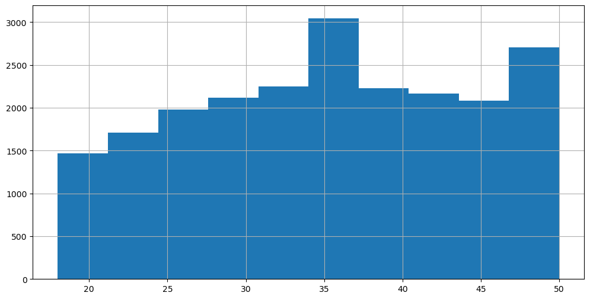

```python
## Run this code but do not edit it. Hit Ctrl+Enter to run the code
# Create a histogram for age
gss["age"].hist()

# Display the created visualization in the notebook
# The semicolon prevents extra output from being displayed
plt.show();
```

Pandas includes built-in plotting methods, like `.hist()`, that use Matplotlib behind the scenes. These methods allow plots and charts to be created directly from a dataframe. From there, Matplotlib functions, accessed through `plt`, can be used to customize and refine these visualizations.

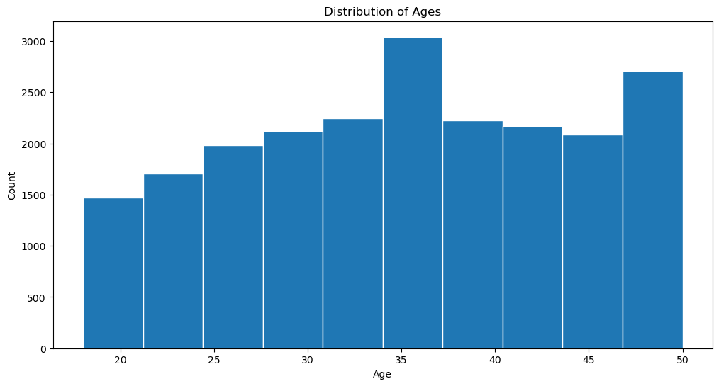

```python
## Run this code but do not edit it. Hit Ctrl+Enter to run the code
# Create a histogram for age
# Add a white border (edgecolor) to each bin
# Do not display grid lines
gss["age"].hist(edgecolor="white", grid=False)

# Add x-axis and y-axis labels
plt.xlabel("Age")
plt.ylabel("Count")

# Add a title
plt.title("Distribution of Ages")
plt.show();
```

**Instructor Note:** `gss["age"].hist()` uses Pandas’ `.hist()` method to create a histogram of the `age` column, while `plt.show();` tells Matplotlib to display the plot.

- Pandas plotting methods (such as `.hist()`) use Matplotlib internally to draw figures. In contrast, functions that begin with `plt.` (e.g., `plt.xlabel()`, `plt.ylabel()`, `plt.title()`, `plt.show();`) come directly from the `matplotlib.pyplot` module and are used to customize or display the plot.
- The semicolon at the end of `plt.show();` prevents Jupyter from displaying additional, unnecessary output. Without a semicolon, Jupyter displays both the plot and the object returned by the plotting command (e.g., `<matplotlib.axes._axes.AxesSubplot at 0x...>`.

A few interesting facts about `age` that are revealed by the histogram:

- Most respondents fall between approximately 25 and 45 years old.
- The distribution peaks around the mid-30s.
- There are relatively more respondents at older ages (45+) than at the youngest ages (around 20).

**3.1 -** Create a histogram for the `wwwhr` variable (hours per week spent on the internet). Label both axes and include a descriptive title.

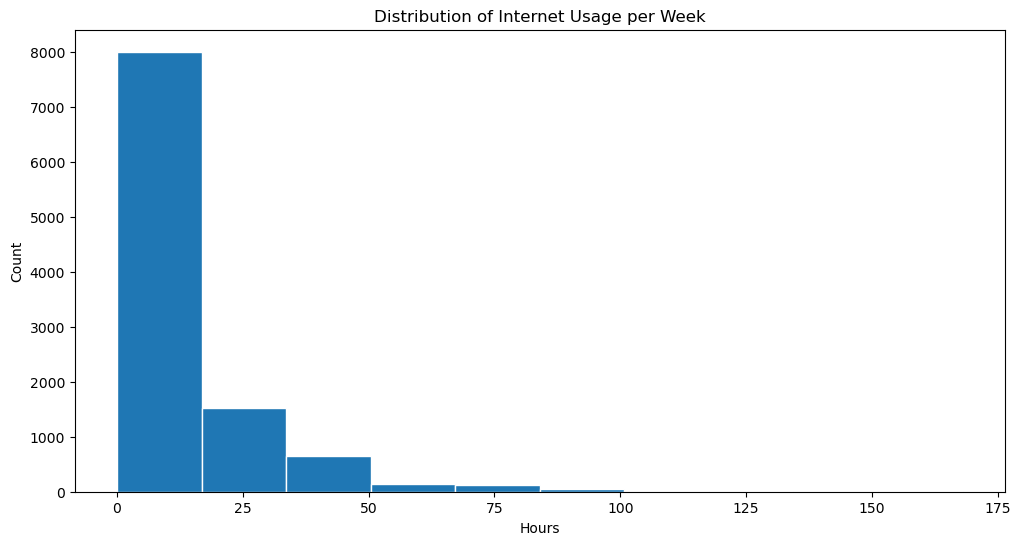

```python
# Your code goes heere
gss["wwwhr"].hist(edgecolor="white", grid=False)
plt.xlabel("Hours")
plt.ylabel("Count")
plt.title("Distribution of Internet Usage per Week")
plt.show();
```

**3.2 –** Use the sentence stems below to describe the distribution and note any features of interest.

- Most respondents report between … and … of internet use per week.
- A small number of respondents report more than … of internet use per week.
- The shape of the distribution of hours spent on the internet per week can be described as …
- The distribution has a tail extending toward …

**Double-click to type a response:**

**Instructor Note:** Here are some of our observations based on what we noticed. Helping students develop the habit of describing patterns and checking for unusual or unexpected results will support better decision-making later in the data analysis process.

#### Boxplots

Histograms show how the values of a quantitative variable are distributed across intervals, but they do not explicitly display summary statistics such as the median or quartiles.

Boxplots, on the other hand, summarize the distribution of a quantitative variable by showing the median, quartiles, and potential outliers. Here, the `.boxplot()` method is used to display a boxplot of `wwwhr`.

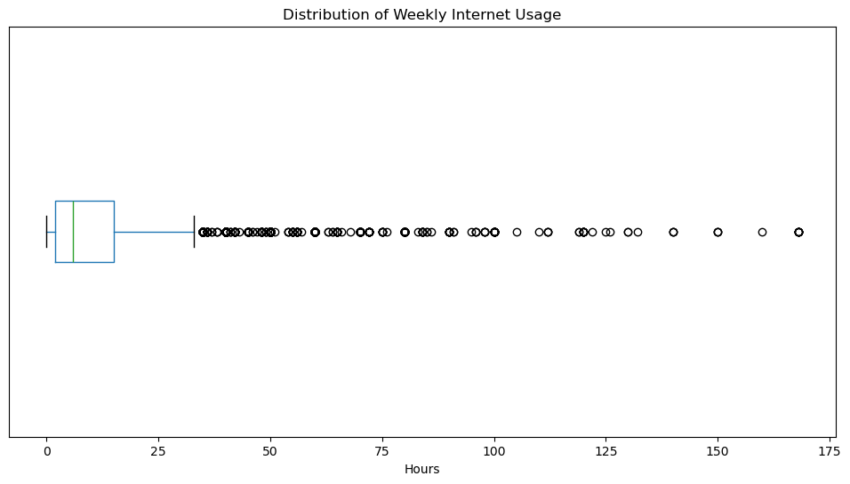

```python
## Run this code but do not edit it. Hit Ctrl+Enter to run the code
# Create a boxplot for wwwhr
# vert=False make he boxplot appear horizontally
gss.boxplot("wwwhr", vert=False, grid=False)

# Label the x-axis and remove the label from the y-axis
plt.xlabel("Hours")
plt.ylabel("")
plt.yticks([])

# Add a title and remove the default subtitle (suptitle)
plt.title("Distribution of Weekly Internet Usage")
plt.suptitle("")
plt.show();
```

**Interpreting the Results:**

- The median (represented by the line inside the box) is around 6–8 hours per week, indicating the typical reported internet usage.
- The middle 50% of values (represented by the box) falls roughly between 2 and 15 hours per week.
- The lower end of the distribution is close to 0 hours, suggesting that some respondents report little to no internet use.
- The upper whisker extends to around 30–40 hours per week, showing the range of most reported values.
- There are several outliers, with some respondents reporting 75, 90, 100, or even over 160 hours per week.

**Check yourself:** If you are unfamiliar with calculating or interpreting medians and quartiles, look at [this video](https://youtu.be/09Cx7xuIXig?si=BPlsXXo4pymngbcK) from Khan Academy (quick refresher) or [this lesson](https://skewthescript.org/1-5) from Skew The Script (detailed lesson with real-world context)..

**Instructor Note:** If students are unfamiliar with calculating or interpreting medians and quartiles, we recommend [this video](https://youtu.be/09Cx7xuIXig?si=BPlsXXo4pymngbcK) from Khan Academy (quick refresher) or [this lesson](https://skewthescript.org/1-5) from Skew The Script (detailed lesson with real-world context).

- `gss.boxplot("wwwhr", vert=False, grid=False)` creates a horizontal box plot without a grid.
- `vert=False` rotates the boxplots so they are horizontal, which makes long category labels easier to read and supports comparison along a shared $x-$axis.
- `grid=False` argument removes grid lines.
- `plt.yticks([])` removes the tick marks and labels from the $y-$axis.
- `plt.suptitle("")` removes the default figure-level title that Pandas automatically adds by defualt.

**3.3 -** Create a horizontal boxplot for the `age` variable. Label both axes and include a descriptive title.

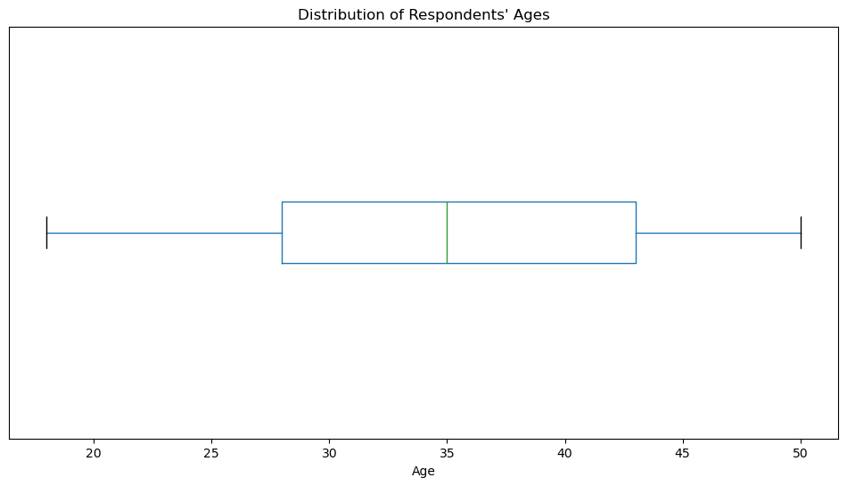

```python
# Your code goes here
gss.boxplot("age", vert=False, grid=False)

# Label the x-axis and remove the label from the y-axis
plt.xlabel("Age")
plt.ylabel("")
plt.yticks([])

# Add a title and remove the default subtitle (suptitle)
plt.title("Distribution of Respondents' Ages")
plt.suptitle("")
plt.show();
```

Unlike the histogram, which groups values into intervals, the boxplot displays key summary statistics of the distribution, including the median, quartiles, and the spread of the middle 50% of the data. In other words, histograms show the shape of a distribution, while boxplots summarize its center, spread, and potential outliers.

Boxplots are also useful for comparing the distribution of a numerical variable across different categories. Now we use the `.boxplot()` method to visualize the distribution of the quantitative variable `wwwhr` across the categorical variable `age_group`:

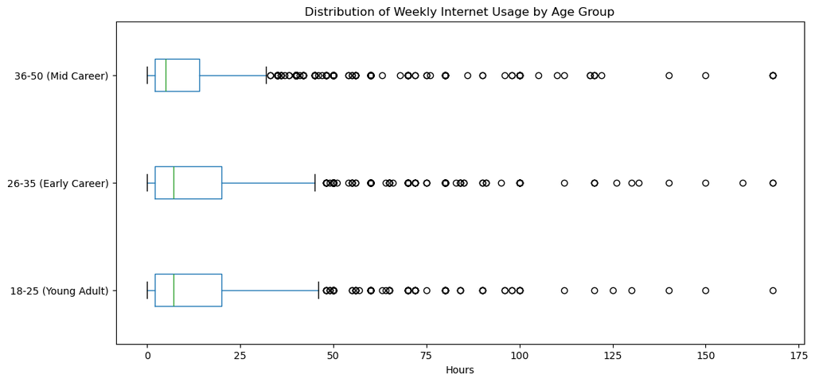

```python
## Run this code but do not edit it. Hit Ctrl+Enter to run the code
# Create a boxplot for wwwhr across age_group
gss.boxplot("wwwhr", by="age_group", vert=False, grid=False)

# Label the x-axis and remove the label from the y-axis
plt.xlabel("Hours")
plt.ylabel("")

# Add a title and remove the default subtitle (suptitle)
plt.title("Distribution of Weekly Internet Usage by Age Group")
plt.suptitle("")
plt.show();
```

**How this works:**

- `gss.boxplot("wwwhr", by="age_group", vert=False, grid=False)` creates separate boxplots of weekly internet usage (`wwwhr`) for each `age_group`
- `by="age_group"` tells Pandas to group the data by age category and draw one boxplot per group.

**3.4 -** Use the sentence stems below to compare reported internet usage across all the age groups.

- The median internet usage for the **Mid Career** group appears to be around … hours per week, compared to about … hours for the younger age groups.
- The middle 50% of internet usage for the **Mid Career** group falls roughly between … and … hours, while the younger groups extend to higher values.
- Overall, the boxplot suggests that … tend to spend more time online, while … show … internet use.

**Double-click to type a response:**

In the survey years 2002, 2008, and 2012, respondents were asked the question,

> *“If you were to consider your life in general these days, how happy or unhappy would you say you are, on the whole?”*

This question corresponds to the variable `hapunhap`. During this period, internet access shifted from dial-up connections to widespread broadband use and, by 2012, to smartphones. Suppose we are interested in how weekly internet usage relates to respondents’ reported happiness levels. First, run the code cell below to display the frequency counts for the responses to this question.

```python
## Run this code but do not edit it. Hit Ctrl+Enter to run the code
# Display frequency counts for each response in the `hapunhap` variable
gss["hapunhap"].value_counts()
```

```
hapunhap
.i:  Inapplicable                  16239
.y:  Not available in this year     3376
Fairly happy                        1118
Very happy                           862
Not very happy                       121
Not at all happy                      28
.d:  Do not Know/Cannot Choose         9
.n:  No answer                         5
Name: count, dtype: int64
```

The response categories of interest are “`Very happy`,” “`Fairly happy`,” “`Not very happy`,” and “`Not at all happy`.”

To compare time spent on the internet across respondents in these categories:

- Create a list of the response categories of interest.
- Use this list to filter out any unwanted or non-substantive responses like, "`.i: Inapplicable`".
- Create a boxplot to compare time spent on the internet across happiness categories.

**3.5 -** Create a list named `hap_unhap` to store the responses `Fairly happy`, `Very happy`, `Not very happy`, and `Not at all happy`.

```python
# Your code goes here
hap_unhap = ["Fairly happy", "Very happy", "Not very happy", "Not at all happy"]

# Display the items in the hap_unhap list
hap_unhap
```

```
['Fairly happy', 'Very happy', 'Not very happy', 'Not at all happy']
```

**Check yourself:** Confirm that your list has 4 elements - `Fairly happy`, `Very happy`, `Not very happy`, and `Not at all happy`.

**3.6 -** Use `.isin()` with the `hap_unhap` list to filter the `gss` dataframe to include only matching happiness responses. Save the result as `hap_unhap_df`.

**Creating an Independent Dataframe:** Students should use `.copy()` when creating a new dataframe. While omitting it may not always cause an error or raise a warning, using `.copy()` ensures that the new dataframe is independent of the original. This helps prevent unintended changes to the original data and avoids potential issues later in the analysis.

```python
# Your code goes here
hap_unhap_df_mask = gss["hapunhap"].isin(hap_unhap)
hap_unhap_df = gss[hap_unhap_df_mask].copy()

# Display the dimensions of hap_unhap_df
hap_unhap_df.shape
```

```
(2129, 45)
```

**Check yourself:** There should be 2129 rows in the filtered `hap_unhap_df` dataframe.

**3.7 -** Use the `hap_unhap_df` to create a boxplot that displays the hours spent on the internet (`wwwhr`) across the happiness levels (`Fairly happy`, `Very happy`, `Not very happy`, and `Not at all happy`). Be sure to label the axes, add $x-$tick marks, remove the default subtitle, and include a descriptive title.

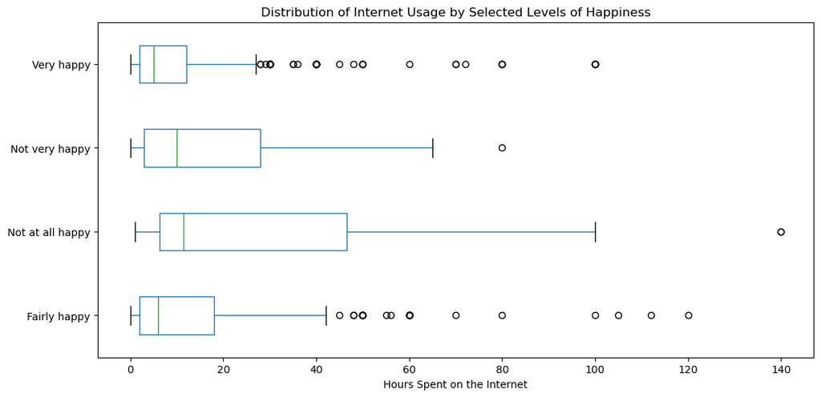

```python
# Your code goes here
hap_unhap_df.boxplot(column="wwwhr", by="hapunhap", vert=False, grid=False)
plt.xlabel("Hours Spent on the Internet")
plt.ylabel("")
plt.title("Distribution of Internet Usage by Selected Levels of Happiness")
plt.suptitle("")
plt.show();
```

**3.8 -** Use the sentence stems below to describe patterns in the boxplot.

- The median number of hours spent on the internet appears to be … for respondents who are **Very happy**, compared to … for respondents who are **Not very happy** or **Not at all happy**.
- The middle 50% of internet usage for respondents who are **Not at all happy** falls roughly between … and … hours, which is … than for the other happiness groups.
- Overall, respondents who report being … tend to spend … time on the internet than those who report being ….

**Double-click to type a response:**

### 4.0 - Visualizing Categorical (Qualitative) Data

When working with categorical data, we focus on how observations are distributed across categories. Unlike numerical data, which consists of values that can be measured and used in calculations, categorical data consists of labels or groups (for example, “Pretty Happy” or “Not too happy”). We summarize categorical data using counts or proportions to understand how responses are distributed across categories.

#### Bar Charts

Bar charts are used to display the counts of a categorical variable. To create a bar chart, we first calculate how often each category appears in the data. Here, we use the `.value_counts()` method to create a frequency table for the `happy` column:

```python
## Run this code but do not edit it. Hit Ctrl+Enter to run the code
# Create a frequency table for happy
gss["happy"].value_counts()
```

```
happy
Pretty happy                      10915
Very happy                         5004
Not too happy                      3014
.i:  Inapplicable                  2721
.n:  No answer                       63
.d:  Do not Know/Cannot Choose       24
.s:  Skipped on Web                  17
Name: count, dtype: int64
```

We can use this output with the `.plot.bar()` method to create a bar chart. Here, the frequency table is plotted to show the distribution of the `happy` variable.

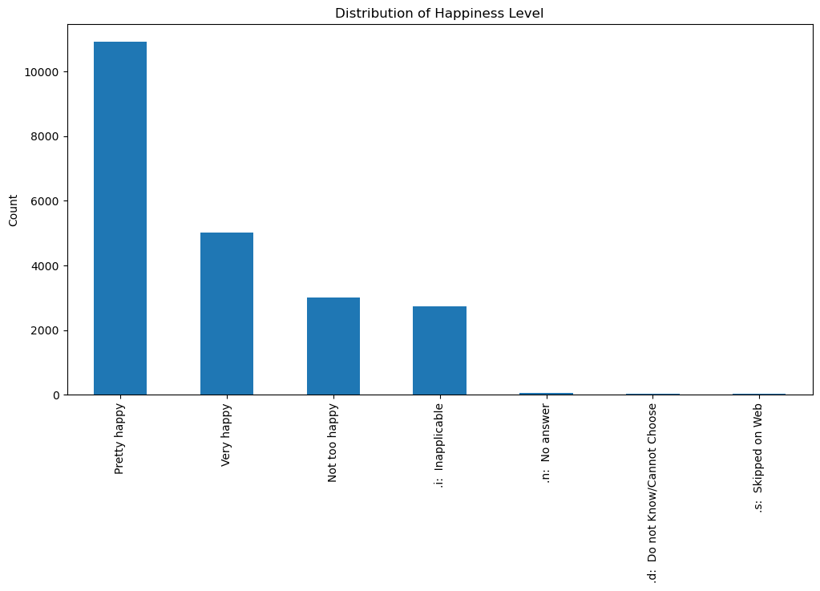

```python
## Run this code but do not edit it. Hit Ctrl+Enter to run the code
# Create a bar chart for happy
gss["happy"].value_counts().plot.bar()
plt.xlabel("")
plt.ylabel("Count")
plt.title("Distribution of Happiness Level")
plt.show();
```

A few interesting facts about `happy` that are revealed by the bar chart:

- Most respondents report being `Pretty happy`, making it the most common response.
- The next most common response is `Very happy`, followed by `“Not too happy”`.
- This suggests that many respondents describe their happiness in moderate to positive terms, rather than at the extremes.
- A smaller number of responses fall into non-substantive categories such as `Inapplicable`, `No answer`, or `Do not know/Cannot Choose`.
- An extremely small number of respondents skipped the question.

**4.1 -** Create a frequency table for the `age_group` variable.

```python
# Your code goes here
gss["age_group"].value_counts()
```

```
age_group
36-50 (Mid Career)      10713
26-35 (Early Career)     7201
18-25 (Young Adult)      3844
Name: count, dtype: int64
```

**4.2 -** Create a bar chart for the `age_group` variable. Label both axes and include a descriptive title.

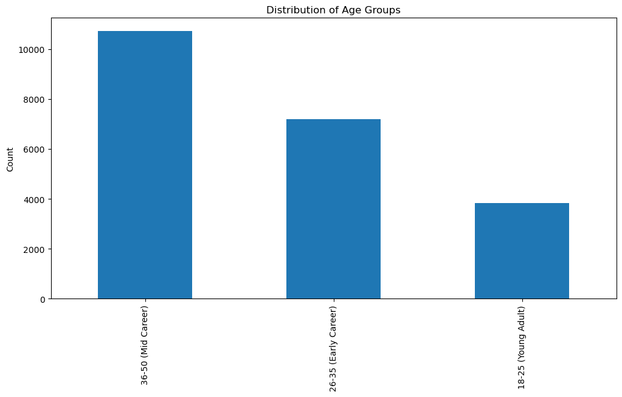

```python
# Your code goes here
gss["age_group"].value_counts().plot.bar()
plt.xlabel("")
plt.ylabel("Count")
plt.title("Distribution of Age Groups")
plt.show();
```

**4.3 —** Use the sentence stems below to describe the bar chart.

- The age group with the highest number of respondents is …
- The age group with the lowest number of respondents is …
- There are more respondents in the … age group than in the … age group.
- The counts across age groups show that …
- A notable feature of the distribution of age groups is …

**Double-click to type a response:**

**Instructor Note:** Here’s our observations for what we noticed. Helping students develop the habit of verifying the output of their code and checking for unusual or unexpected results will support better decision-making later in the data analysis process.

- The age group with the highest number of respondents is the `36–50 (Mid Career)` group.
- The age group with the lowest number of respondents is the `18–25 (Young Adult)` group.
- There are more respondents in the `36–50 (Mid Career)` age group than in the `26–35 (Early Career)` age group.
- The counts across age groups show that respondents are more concentrated in older age groups than in younger age groups.
- A notable feature of the distribution of age groups is the steady decrease in the number of respondents from the oldest to the youngest age group.

We can explore the relationship between two variables by visualizing them both at once. When both variables are categorical, side-by-side bar charts allow us to compare categories across groups. To create this type of chart, we first construct a two-way frequency table.

Here, we use the `pd.crosstab()` function to create a two-way frequency table between `degree` (categorical) and `happy` (categroical):

```python
## Run this code but do not edit it. Hit Ctrl+Enter to run the code
# Create a two-way frequency table between degree and happy
pd.crosstab(gss["degree"], gss["happy"])
```

| happy degree | .d: Do not Know/Cannot Choose | .i: Inapplicable | .n: No answer | .s: Skipped on Web | Not too happy | Pretty happy | Very happy |
| --- | --- | --- | --- | --- | --- | --- | --- |
| .d: Do not Know/Cannot Choose | 0 | 2 | 0 | 0 | 4 | 6 | 2 |
| .n: No answer | 0 | 2 | 1 | 0 | 1 | 11 | 3 |
| .s: Skipped on Web | 0 | 0 | 0 | 0 | 0 | 1 | 0 |
| Associate/junior college | 1 | 240 | 4 | 0 | 240 | 985 | 437 |
| Bachelor's | 9 | 500 | 7 | 5 | 426 | 2188 | 1189 |
| Graduate | 0 | 215 | 6 | 0 | 189 | 1110 | 583 |
| High school | 10 | 1437 | 30 | 9 | 1618 | 5525 | 2264 |
| Less than high school | 4 | 325 | 15 | 3 | 536 | 1089 | 526 |

**4.4 —** Focus on the `High school` and `Less than high school` rows, and the `Not too happy`, `Pretty happy`, and `Very happy` columns. Use the sentence stems below to describe the results and patterns two-way frequency table.

- For respondents with a **high school** education, the most common happiness category is …
- For respondents with **less than a high school** education, the most common happiness category is …
- Comparing the two rows, the proportion of the counts of `Pretty happy` responses is higher for respondents with a … education than for those with … education.
- Comparing the two rows, the counts suggest that …
- A notable difference between these two education groups is …

**Double-click to type a response:**

**Instructor Note:** Here are some of our observations based on what we noticed. Helping students develop the habit of describing patterns and checking for unusual or unexpected results will support better decision-making later in the data analysis process.

- For respondents with a **high school** education, the most common happiness category is **Pretty happy**.
- For respondents with **less than a high school** education, the most common happiness category is also **Pretty happy**.
- Comparing the two rows, the proportion of the counts of **Pretty happy** responses is higher for respondents with a **high school** education than for those with **less than high school** education.
- Comparing the two rows, the counts suggest that respondents with a **high school** education appear more frequently in each happiness category than those with **less than a high school** education.
- A notable difference between these two education groups is that the **high school** group has substantially higher counts of both **Pretty happy** and **Very happy** respondents.

Students may be tempted to compare counts across groups when describing differences in the two-way table. However, because the group sizes differ, counts can be misleading. In this case, students should compare proportions instead, as proportions reflect the share of responses within each group and allow for a more meaningful comparison of distributions across categories.

The two-way table above includes several non-substantive categories, like `.i: Inapplicable`, `.n: No answer`, `.s: Skipped on Web`. These responses to the survey question do not represent reported degree or happiness levels. To focus our comparison on respondents who provided meaningful answers, we need to remove these categories.

```python
## Run this code but do not edit it. Hit Ctrl+Enter to run the code
# Define the degree and happy categories we want to include
deg_cat = ["Less than high school", "High school", "Bachelor's", "Graduate"]
hap_cat = ["Very happy", "Pretty happy", "Not too happy"]

# Create a mask that keeps only rows with selected degree and happy categories
deg_hap_mask = (gss["happy"].isin(hap_cat)) & (gss["degree"].isin(deg_cat))

# Apply the mask to create a filtered dataframe
deg_hap_df = gss[deg_hap_mask].copy()

# Create a two-way frequency table for degree and happiness
pd.crosstab(deg_hap_df["degree"], deg_hap_df["happy"])
```

| happy degree | Not too happy | Pretty happy | Very happy |
| --- | --- | --- | --- |
| Bachelor's | 426 | 2188 | 1189 |
| Graduate | 189 | 1110 | 583 |
| High school | 1618 | 5525 | 2264 |
| Less than high school | 536 | 1089 | 526 |

**4.5 —** After running the code above, talk through the questions below with a classmate or the instructor. You **do not** need to write anything or change the code.

- What do the lists `deg_cat` and `hap_cat` represent?
- What does `.isin()` do in this code?
- What does the `&` operator mean in the line that creates `deg_hap_mask`?
- What rows from the `gss` dataframe are kept after applying the mask?
- Why do we create the two-way table **after** filtering the data?

**Instructor Note:** This code demonstrates a common data-analysis workflow: Identify categories of interest → Filter the data → Summarize the filtered data.

- The lists `deg_cat` and `hap_cat` explicitly define which degree and happiness categories are considered substantive for this analysis. Making these choices visible helps students see that filtering is a deliberate analytic decision.
- The `.isin()` method is used to check, row by row, whether each respondent’s value appears in the selected categories. Each call to `.isin()` returns a boolean `Series` of `True`/`False` values.
- The `&` operator combines the two boolean `Series` so that a row is kept only if **both** conditions are true: the respondent has one of the selected happiness levels and one of the selected degree levels.
- Applying the mask to `gss` creates a filtered DataFrame (`deg_hap_df`) that includes only respondents relevant to the comparison of interest.
- The final `pd.crosstab()` call summarizes the filtered data by counting how many respondents fall into each combination of degree and happiness categories. This table is then ready to be interpreted or visualized using a side-by-side bar chart.

Emphasize that the structure of the table and any subsequent visualization using `deg_hap_df` directly reflects the filtering choices made earlier in the code.

Now that we have filtered the data and created a two-way frequency table, we can visualize the results using a side-by-side bar chart.

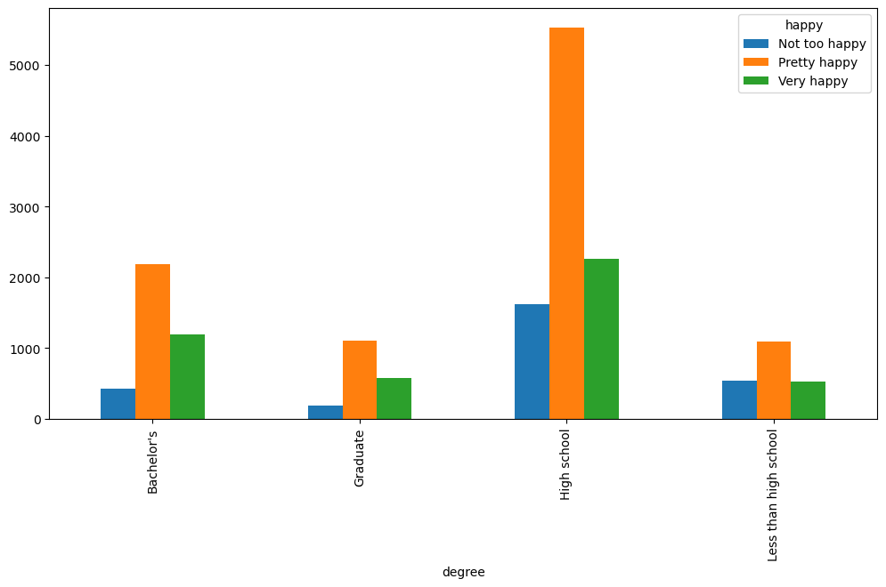

```python
# Run this code but do not edit it. Hit Ctrl+Enter to run the code
# Create a side-by-side bar chart for degree and happy
pd.crosstab(deg_hap_df["degree"], deg_hap_df["happy"]).plot.bar()
plt.show();
```

Here, `plt` functions are used to customize different parts of the visualization.

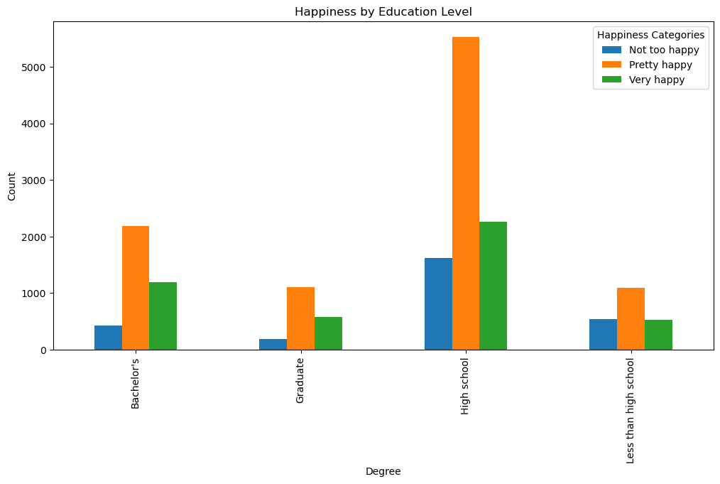

```python
# Run this code but do not edit it. Hit Ctrl+Enter to run the code
# Create a side-by-side bar chart for degree and happy
pd.crosstab(deg_hap_df["degree"], deg_hap_df["happy"]).plot.bar()

#  Label the axes and the title
plt.xlabel("Degree")
plt.ylabel("Count")
plt.title("Happiness by Education Level")

# Add a legend title
plt.legend(title="Happiness Categories")
plt.show();
```

While these bar charts show total counts for each education level, they do not account for differences in group size. When this is the case, proportions are a better alternative for comparing across groups.

Using `normalize="index"` converts each row to proportions, so the values in each row add up to 1. Here, we create a table of proportions using the filtered `deg_hap_df` `DataFrame`.

**Reminder:** Before calculating proportions, we filtered the data to include only the response categories “Not too happy,” “Pretty happy,” and “Very happy.”

As a result, even though the values in each row sum to 1, these proportions represent only respondents who selected one of these options, not all respondents in the dataset.

**Interpretation:** When describing your results, be sure to say “among respondents who answered with one of these options,” rather than “all respondents.”

```python
## Run this code but do not edit it. Hit Ctrl+Enter to run the code
# Create a two-way proportions table between degree and happy
pd.crosstab(deg_hap_df["degree"], deg_hap_df["happy"], normalize="index")
```

| happy degree | Not too happy | Pretty happy | Very happy |
| --- | --- | --- | --- |
| Bachelor's | 0.112017 | 0.575335 | 0.312648 |
| Graduate | 0.100425 | 0.589798 | 0.309777 |
| High school | 0.172000 | 0.587329 | 0.240672 |
| Less than high school | 0.249186 | 0.506276 | 0.244537 |

**Reminder:** When comparing groups, do not rely on counts alone. Counts reflect both the size of the group and how responses are distributed, which can lead to misleading conclusions. Instead, compare proportions, as they show the share of responses within each group and provide a more meaningful comparison.

**Example:** Suppose you are comparing responses to the `happy` variable across two groups. If 40 respondents in Group A report being “Pretty Happy” and 15 respondents in Group B report being “Pretty Happy,” it may seem like Group A has more happy respondents. However, if Group A has 80 total respondents (50%) and Group B has 20 total respondents (75%), a larger share of Group B is “Pretty Happy,” even though the count is smaller.

**4.6 —** Focus only on the **High school** and **Less than high school** rows. Use the sentence stems below to compare the two-way frequency table to the proportions table.

- The frequency table emphasizes …, while the proportions table shows ….
- Proportions provide a more accurate way to compare … because they show the … of each group in a category, rather than counts that are influenced ….
- Within each degree category in the proportions table most respondents report …, with smaller shares reporting … or ….
- A higher proportion of respondents with … education report being … compared to those with ….
- As education level increases, the proportion of respondents reporting … tends ….

**Double-click to type a response:**

**Instructor Note:**

- The frequency table emphasizes differences in total counts, while the proportions table shows how happiness is distributed within each degree category.
- Proportions provide a more accurate way to compare across groups because they show the share of each group in a category, rather than counts that are influenced by group size.
- Within each degree category in the proportions table most respondents report being **Pretty happy**, with smaller shares reporting being **Not too happy** or **Very happy**.
- A higher proportion of respondents with **Less than high school** education report being **Not too happy** compared to those with **Bachelor’s** or **Graduate** degrees.
- As education level increases, the proportion of respondents reporting being **Not too happy** tends to decrease.

Here, we visualize these proportions:

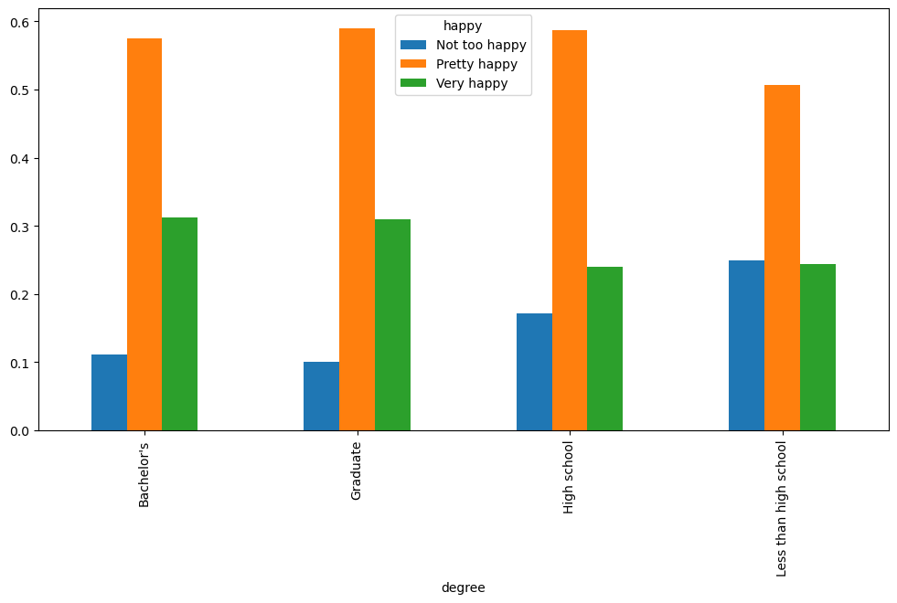

```python
## Run this code but do not edit it. Hit Ctrl+Enter to run the code
# Create a side-by-side bar chart between degree and happy using
# the deg_hap_df dataframe
pd.crosstab(deg_hap_df["degree"], deg_hap_df["happy"], normalize="index").plot.bar()
plt.show();
```

Suppose we want to compare happiness across different types of high school credentials, specifically the type of diploma earned. The variable `dipged` records the type of high school credential earned by each respondent.

```python
## Run this code but do not edit it. Hit Ctrl+Enter to run the code
# Display the unique labels for dipged
gss["dipged"].unique()
```

```
array(['.y:  Not available in this year', 'High School diploma',
       '.i:  Inapplicable', 'GED', 'Other', '.n:  No answer',
       '.d:  Do not Know/Cannot Choose', '.s:  Skipped on Web'],
      dtype=object)
```

To examine how happiness relates to high school credentials:

- Create a list of the substantive categories for dipged.
- Use this list to filter the full gss dataframe to include only these categories.
- Run the code below to view the full list of categories.

**4.7 —** Create a list named `dip_cat` that stores the three types of high school credentials reported by respondents.

```python
# Your code goes here
dip_cat = ["GED", "High School diploma", "Other"]

# Display the items in the dip_cat list
dip_cat
```

```
['GED', 'High School diploma', 'Other']
```

**Check yourself:** Confirm that your list has 3 elements - `GED`, `High School diploma`, and `Other`.

The code below creates a boolean mask that can be used to filter the `gss` dataframe, keeping only rows that match the selected diploma and happiness categories.

```python
## Run this code but do not edit it. Hit Ctrl+Enter to run the code
# Create a mask that keeps only rows with selected diploma and happy categories
dip_hap_mask = (gss["happy"].isin(hap_cat)) & (gss["dipged"].isin(dip_cat))
```

**4.8 —** Apply `dip_hap_mask` to the `gss` dataframe. Save the filtered data as `dip_hap_df`.

```python
# Your code goes here
dip_hap_df = gss[dip_hap_mask]
```

**4.9 —** Use the `dip_hap_df` to create a two-way proportion table comparing `dipged` and `happy`.

```python
# Your code goes here
pd.crosstab(dip_hap_df["dipged"], dip_hap_df["happy"], normalize="index")
```

| happy dipged | Not too happy | Pretty happy | Very happy |
| --- | --- | --- | --- |
| GED | 0.259580 | 0.582200 | 0.158220 |
| High School diploma | 0.164947 | 0.581260 | 0.253793 |
| Other | 0.179487 | 0.512821 | 0.307692 |

**Check yourself:** Confirm that the table looks like this:

| **happy** | **Not too happy** | **Pretty happy** | **Very happy** |
| --- | --- | --- | --- |
| **dipged** |  |  |  |
| **GED** | 0.259580 | 0.582200 | 0.158220 |
| **High School diploma** | 0.164947 | 0.581260 | 0.253793 |
| **Other** | 0.179487 | 0.512821 | 0.307692 |

**4.10 —** Create a side-by-side bar chart using the two-way proportions table created from the `dip_hap_df` dataframe. Be sure to label the axes and include descriptive titles for both the chart and the legend.

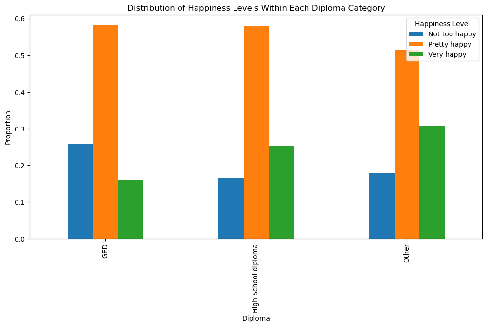

```python
# Your code goes here
pd.crosstab(dip_hap_df["dipged"], dip_hap_df["happy"], normalize="index").plot.bar()
plt.xlabel("Diploma")
plt.ylabel("Proportion")
plt.title("Distribution of Happiness Levels Within Each Diploma Category")
plt.legend(title="Happiness Level")
plt.show();
```

**4.11 -** Describe how the proportions for the happiness levels vary across the diploma categories.

**Double-click to type a response:**

**Instructor Note:** The points below summarize key patterns visible in the side-by-side bar chart. Encourage students to connect these observations directly to the plotted proportions rather than relying on prior expectations.

- Across all diploma categories, **Pretty happy** is the most common reported happiness level.
- Respondents with a **GED** have the highest proportion of **Not too happy** responses and the lowest proportion of **Very happy** responses.
- Respondents with a **High school diploma** show a smaller share of **Not too happy** responses and a larger share of **Very happy** responses compared to those with a GED.
- The **Other** diploma category has the highest proportion of **Very happy** responses and the lowest proportion of **Pretty happy**, suggesting relatively higher reported happiness.

### 5.0 - Notebook Summary

In this notebook, we used visualizations to explore and compare patterns in data by:

- examining the distribution of variables, and
- comparing patterns across different groups.

In data analysis, creating visualizations is also a form of data moves. Visual data moves involve transforming data into graphical representations to support interpretation and comparison. Here, we focused on using visualizations to explore distributions and relationships.

- Histograms show the distribution of a single quantitative variable.
- Bar charts compare counts or proportions across categories.
- Boxplots compare distributions across groups using medians, spread, and outliers.

The visualizations created here demonstrate how different plots support different data moves, helping reveal patterns that are not always clear from tables alone.